# Tutorial: Quantifying Natural Selection

Matt Barbour  
April 4, 2018

### Evolution by Natural Selection

Requires 3 ingredients:

- Variation in phenotypes
- Variation in fitness
- Heritable phenotypic variation

### Quantifying Natural Selection

**Selection differential**: change in mean phenotype, \( \bar{z} \), after selection

\[ S=\bar{z}^*-\bar{z} \]

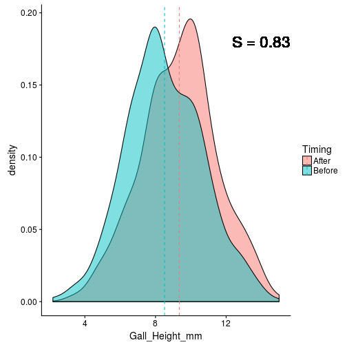

### Standardized Selection Differential

\[ S'=\frac{S}{\sigma_z}=B'=0.39 \]

\[ B=\frac{S}{\sigma^2_z}=0.18 \]

\( \sigma_z \): standard deviation of the phenotype before selection

\( \sigma^2_z \): variance of the phenotype before selection

### Alternative Calculation of Selection Differential

Covariance between relative fitness \( w \) and the phenotype:

\[ S=cov(w,z) \]

Relative fitness is calculated as absolute fitness (\( W \)) divided by the mean fitness of the population: \[ w=\frac{W}{\bar{W}} \]

This becomes especially useful when we want to quantify selection acting on multiple traits. This approach enables use to calculate selection gradients, which corresponds to the direct effects of selection. Selection differentials, on the other hand, quantify both the direct and indirect effects of selection when multiple traits are considered (because they cannot take into account selection imposed by other traits).

Note that for a single phenotype, the selection differential corresponds to the selection gradient \( \beta \).

### Alternative Calculation of Selection Differential

|  | Intercept | B | B' = B * sd(z) | S = B * var(z) |
| --- | --- | --- | --- | --- |
| Estimate | 1 | 0.18 | 0.39 | 0.83 |

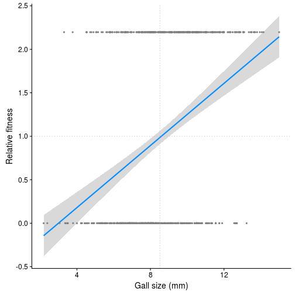

Note that \( S'=\beta' \).

### A quick digression

```
                 term    estimate   std.error statistic   p.value
1         (Intercept) 0.094453278 0.456976926 0.2066916 0.8363108
2      Gall_Height_mm 0.026772394 0.107364961 0.2493588 0.8031564
3 I(Gall_Height_mm^2) 0.008780552 0.006121287 1.4344290 0.1518965
```

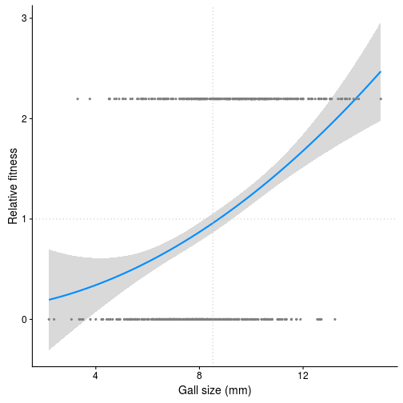

### Comparing Selection in Different Environments

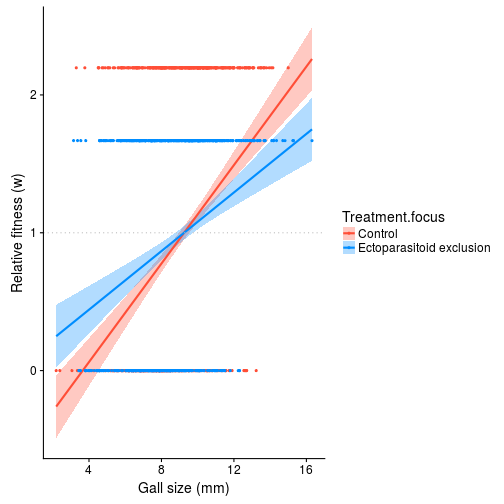

### Comparing Selection in Different Environments

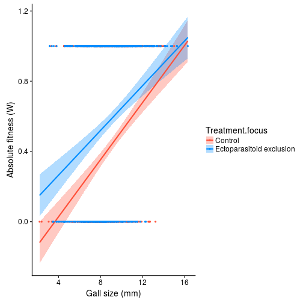

|  | W_bar | b | B = b / W_bar | B' = B * sd(z) | S = B * var(z) |
| --- | --- | --- | --- | --- | --- |
| Complex | 0.46 | 0.08 | 0.18 | 0.39 | 0.83 |
| Simple | 0.60 | 0.06 | 0.11 | 0.25 | 0.58 |

### Comparing Selection in Different Environments

```
[1] 0.5295383
```

```
                                                                              term
1                                                                      (Intercept)
2                                         I(Gall_Height_mm - mean(Gall_Height_mm))
3 I(Gall_Height_mm - mean(Gall_Height_mm)):Treatment.focusEctoparasitoid exclusion
     estimate  std.error statistic       p.value
1  1.06057999 0.02672626 39.683066 3.179406e-226
2  0.17860061 0.01684994 10.599481  3.107384e-25
3 -0.05831926 0.02382627 -2.447687  1.450927e-02
```

```
                                                                              term
1                                                                      (Intercept)
2                                         I(Gall_Height_mm - mean(Gall_Height_mm))
3 I(Gall_Height_mm - mean(Gall_Height_mm)):Treatment.focusEctoparasitoid exclusion
     estimate  std.error statistic       p.value
1  0.99992962 0.02550624 39.203333 1.754104e-222
2  0.17862407 0.01608076 11.107937  1.891144e-27
3 -0.07232552 0.02273863 -3.180733  1.503769e-03
```

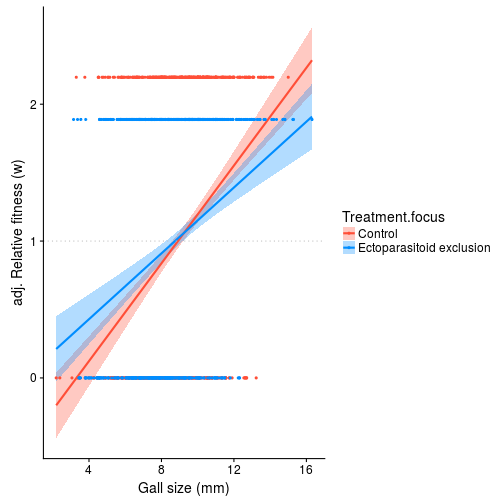